| Explore and Summarize Red Wine Dataset, Mada AlAhmadi (Udacity Data Analyst) |
| --- |

# Data Exploration

```
## 'data.frame':    1599 obs. of  13 variables:
##  $ X                   : int  1 2 3 4 5 6 7 8 9 10 ...
##  $ fixed.acidity       : num  7.4 7.8 7.8 11.2 7.4 7.4 7.9 7.3 7.8 7.5 ...
##  $ volatile.acidity    : num  0.7 0.88 0.76 0.28 0.7 0.66 0.6 0.65 0.58 0.5 ...
##  $ citric.acid         : num  0 0 0.04 0.56 0 0 0.06 0 0.02 0.36 ...
##  $ residual.sugar      : num  1.9 2.6 2.3 1.9 1.9 1.8 1.6 1.2 2 6.1 ...
##  $ chlorides           : num  0.076 0.098 0.092 0.075 0.076 0.075 0.069 0.065 0.073 0.071 ...
##  $ free.sulfur.dioxide : num  11 25 15 17 11 13 15 15 9 17 ...
##  $ total.sulfur.dioxide: num  34 67 54 60 34 40 59 21 18 102 ...
##  $ density             : num  0.998 0.997 0.997 0.998 0.998 ...
##  $ pH                  : num  3.51 3.2 3.26 3.16 3.51 3.51 3.3 3.39 3.36 3.35 ...
##  $ sulphates           : num  0.56 0.68 0.65 0.58 0.56 0.56 0.46 0.47 0.57 0.8 ...
##  $ alcohol             : num  9.4 9.8 9.8 9.8 9.4 9.4 9.4 10 9.5 10.5 ...
##  $ quality             : int  5 5 5 6 5 5 5 7 7 5 ...
```

```
##        X          fixed.acidity   volatile.acidity  citric.acid
##  Min.   :   1.0   Min.   : 4.60   Min.   :0.1200   Min.   :0.000
##  1st Qu.: 400.5   1st Qu.: 7.10   1st Qu.:0.3900   1st Qu.:0.090
##  Median : 800.0   Median : 7.90   Median :0.5200   Median :0.260
##  Mean   : 800.0   Mean   : 8.32   Mean   :0.5278   Mean   :0.271
##  3rd Qu.:1199.5   3rd Qu.: 9.20   3rd Qu.:0.6400   3rd Qu.:0.420
##  Max.   :1599.0   Max.   :15.90   Max.   :1.5800   Max.   :1.000
##  residual.sugar     chlorides       free.sulfur.dioxide
##  Min.   : 0.900   Min.   :0.01200   Min.   : 1.00
##  1st Qu.: 1.900   1st Qu.:0.07000   1st Qu.: 7.00
##  Median : 2.200   Median :0.07900   Median :14.00
##  Mean   : 2.539   Mean   :0.08747   Mean   :15.87
##  3rd Qu.: 2.600   3rd Qu.:0.09000   3rd Qu.:21.00
##  Max.   :15.500   Max.   :0.61100   Max.   :72.00
##  total.sulfur.dioxide    density             pH          sulphates
##  Min.   :  6.00       Min.   :0.9901   Min.   :2.740   Min.   :0.3300
##  1st Qu.: 22.00       1st Qu.:0.9956   1st Qu.:3.210   1st Qu.:0.5500
##  Median : 38.00       Median :0.9968   Median :3.310   Median :0.6200
##  Mean   : 46.47       Mean   :0.9967   Mean   :3.311   Mean   :0.6581
##  3rd Qu.: 62.00       3rd Qu.:0.9978   3rd Qu.:3.400   3rd Qu.:0.7300
##  Max.   :289.00       Max.   :1.0037   Max.   :4.010   Max.   :2.0000
##     alcohol         quality
##  Min.   : 8.40   Min.   :3.000
##  1st Qu.: 9.50   1st Qu.:5.000
##  Median :10.20   Median :6.000
##  Mean   :10.42   Mean   :5.636
##  3rd Qu.:11.10   3rd Qu.:6.000
##  Max.   :14.90   Max.   :8.000
```

# Univariate Plots

### Quality

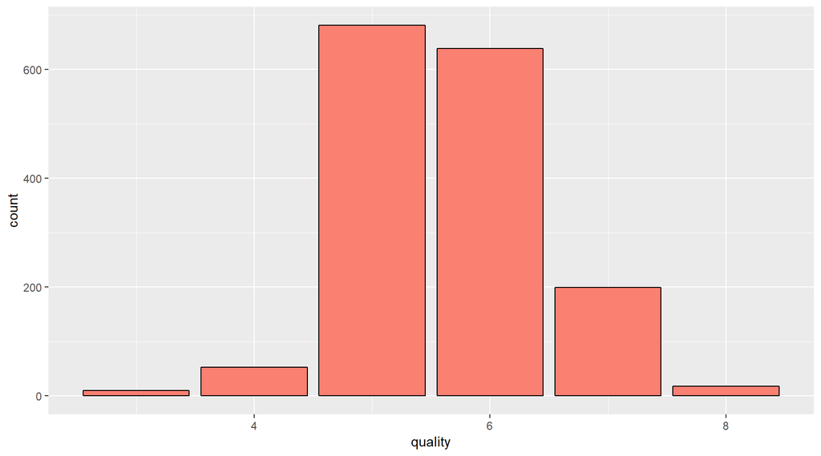

- First, know the the levels of our dataset qulaity
- The above plot show the wine quality range

### Quality Levels

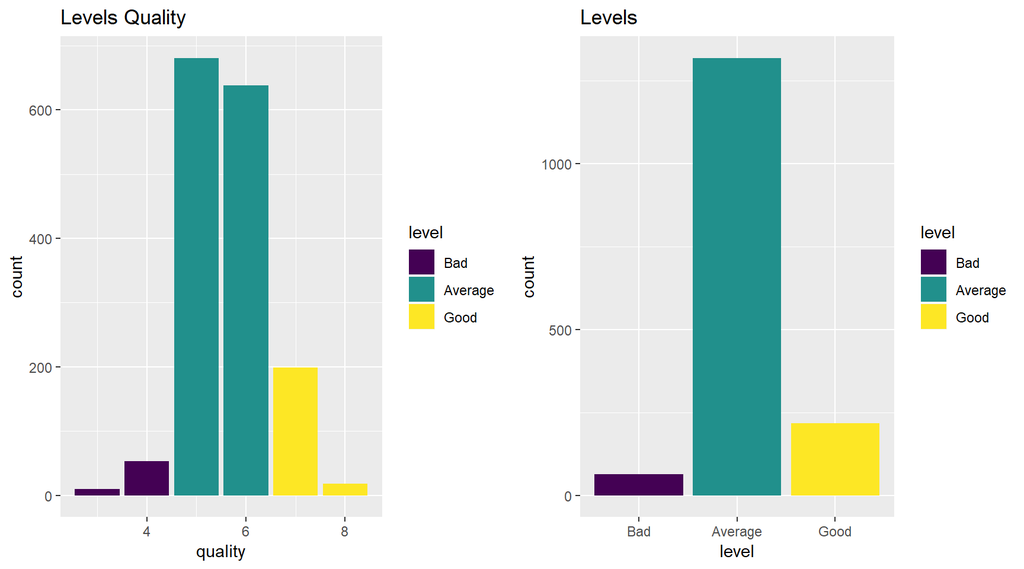

- The plots above showen that the majority of the wines are average (5-6) and very few are bad or good(3,4,and 8)

### Fixed Acidity

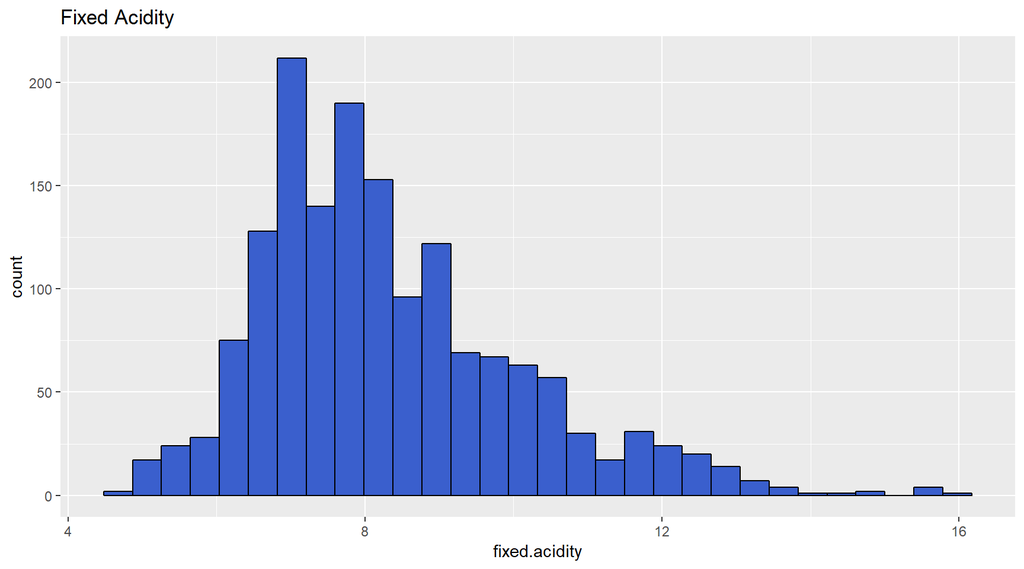

```
##    Min. 1st Qu.  Median    Mean 3rd Qu.    Max.
##    4.60    7.10    7.90    8.32    9.20   15.90
```

- From the above plot we can see that the fixed acidity is “Right skewed” distribution

### Volatile Acidity

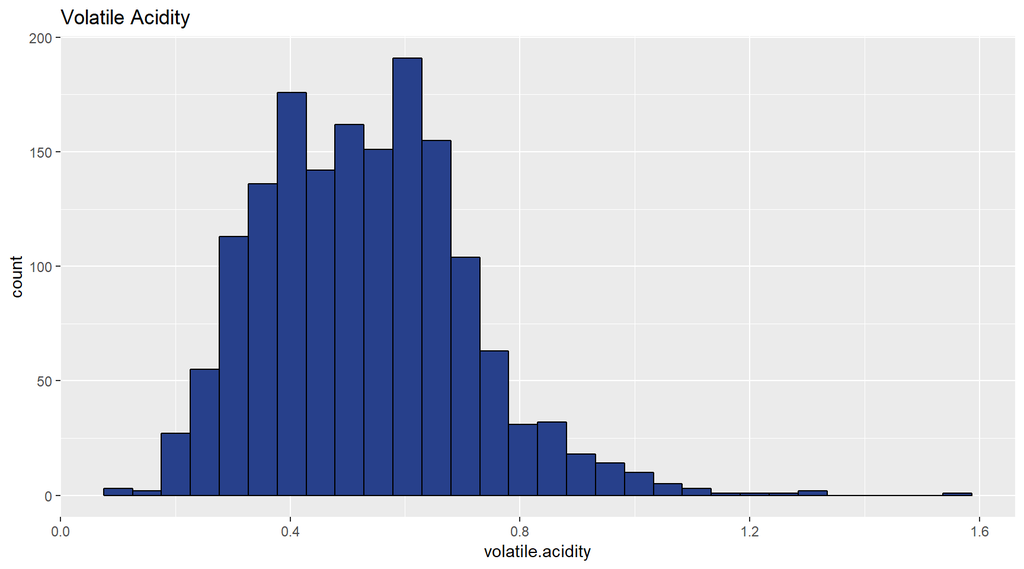

```
##    Min. 1st Qu.  Median    Mean 3rd Qu.    Max.
##  0.1200  0.3900  0.5200  0.5278  0.6400  1.5800
```

- The above plot kinda look “bell shape plot”
- Have two peaks
- Normal distribution

### Citric Acid

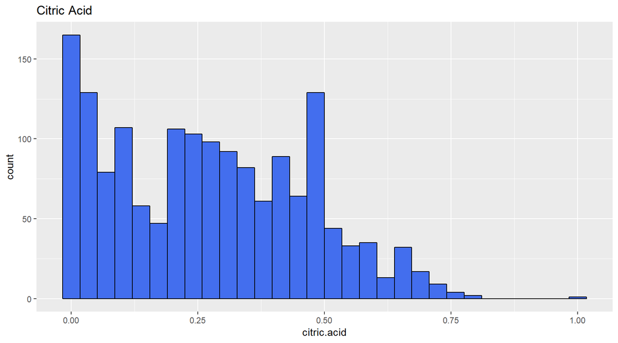

```
##    Min. 1st Qu.  Median    Mean 3rd Qu.    Max.
##   0.000   0.090   0.260   0.271   0.420   1.000
```

- The above plot shows clearley that there is two peaks

### Alcohol

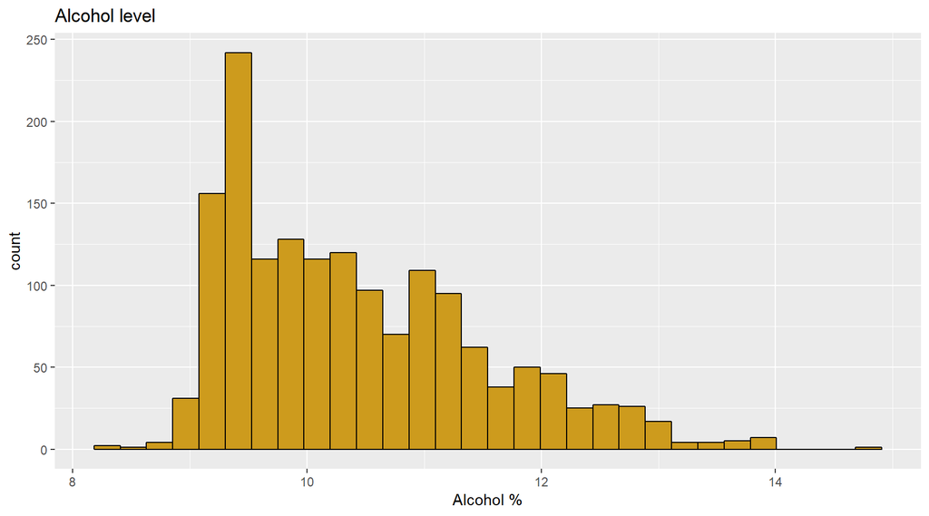

```
##    Min. 1st Qu.  Median    Mean 3rd Qu.    Max.
##    8.40    9.50   10.20   10.42   11.10   14.90
```

- I was thinking to plot this because i think alcohol is one of the strongest factors that affect the quality of the wine
- We can see that the alcohol plot is “right skewed” distribution which mean the majority of the wines alcohol rate are less than 11%

### pH Level

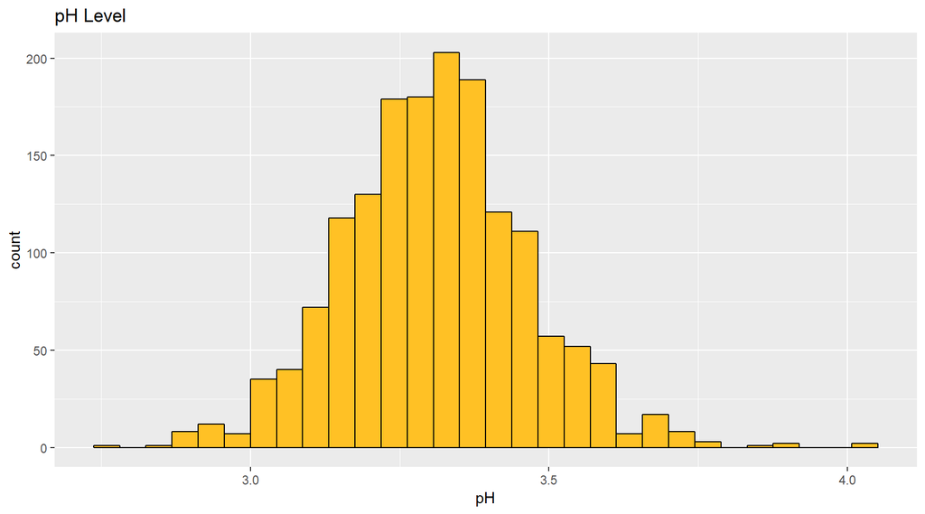

```
##    Min. 1st Qu.  Median    Mean 3rd Qu.    Max.
##   2.740   3.210   3.310   3.311   3.400   4.010
```

- Most wines pH level is at 3.31%
- Normal distribution

### Residual sugar

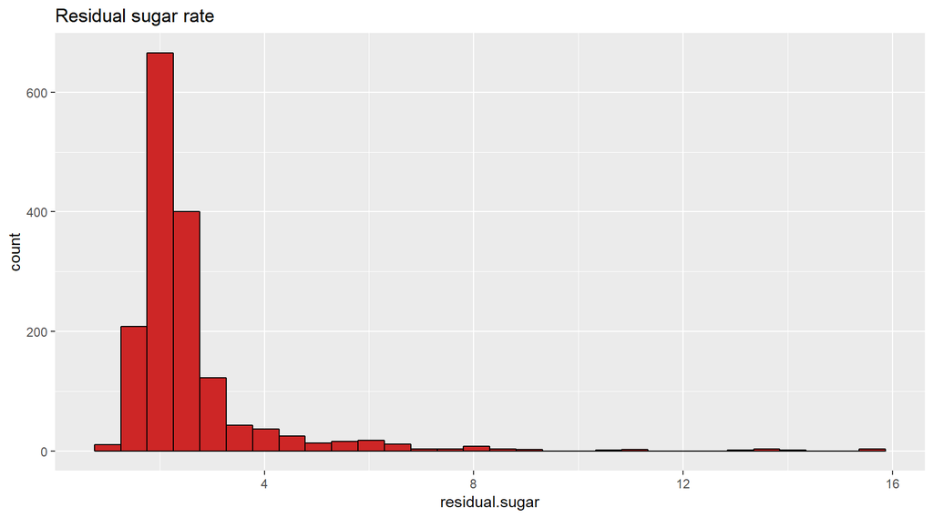

```
##    Min. 1st Qu.  Median    Mean 3rd Qu.    Max.
##   0.900   1.900   2.200   2.539   2.600  15.500
```

- The plot above is right-skewed distribution
- The majority of wines RS is less than 2.6%

### Density

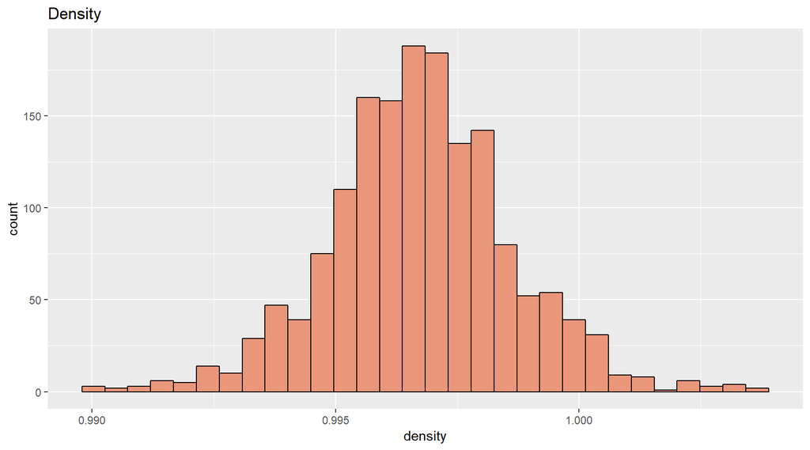

```
##    Min. 1st Qu.  Median    Mean 3rd Qu.    Max.
##  0.9901  0.9956  0.9968  0.9967  0.9978  1.0037
```

- Normal distribution

### Sulphates

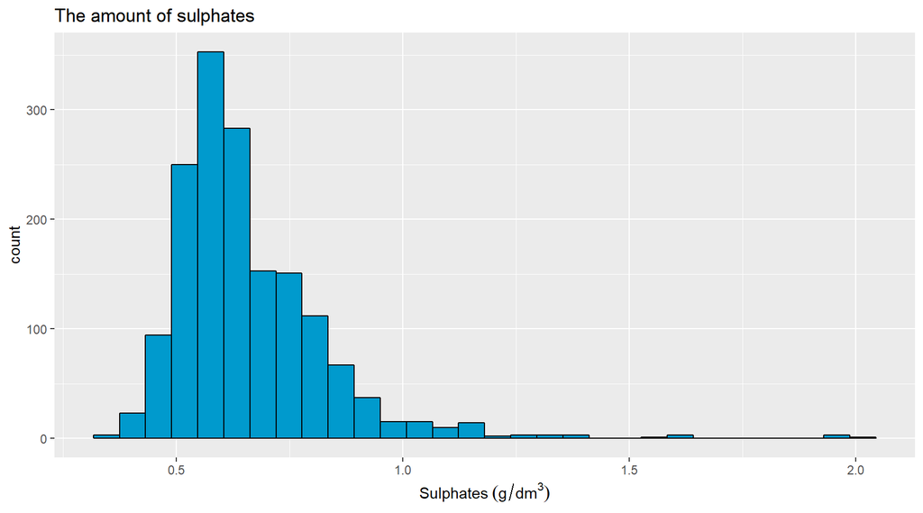

```
##    Min. 1st Qu.  Median    Mean 3rd Qu.    Max.
##  0.3300  0.5500  0.6200  0.6581  0.7300  2.0000
```

### Sulfur Dioxide

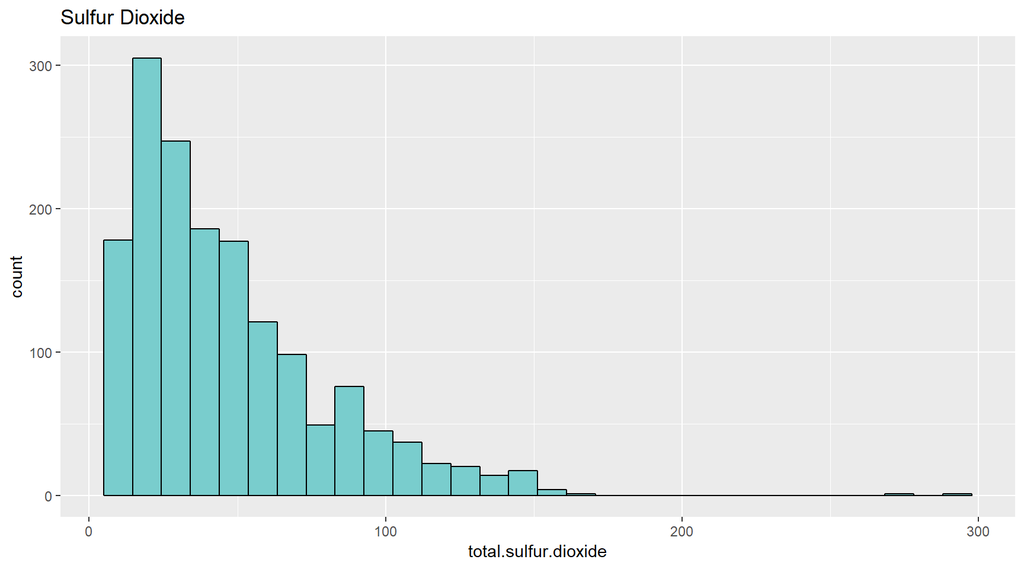

```
##    Min. 1st Qu.  Median    Mean 3rd Qu.    Max.
##    6.00   22.00   38.00   46.47   62.00  289.00
```

- Most of the wines Sulfur Dioxide less than 62.00(3rd Qu.)

### Free Sulfur Dioxide

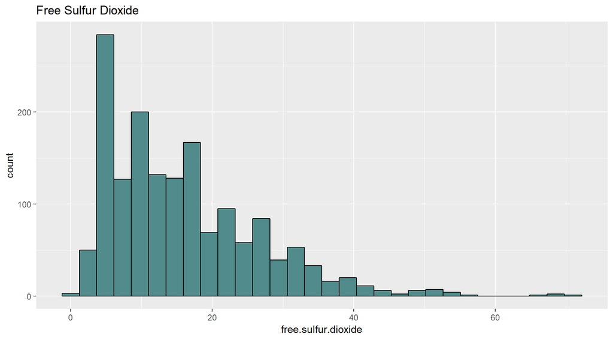

```
##    Min. 1st Qu.  Median    Mean 3rd Qu.    Max.
##    1.00    7.00   14.00   15.87   21.00   72.00
```

- The above plot free sulfur dioxide is Right-skewed

### Chlorides

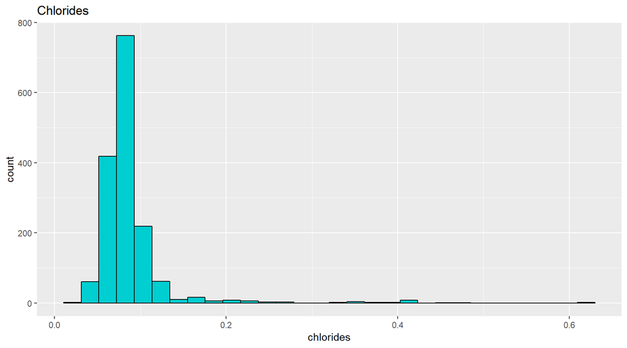

[output not shown]

- Create this plot to show the amount of salt in the wine
- Right-Skewed (long right tail)

# Univariate Analysis

### What is the structure of your dataset?

Red Wine dataset contains 1599 observations & 13 variable

### What is/are the main feature(s) of interest in your dataset?

The “quality”" of the wine

### What other features in the dataset do you think will help support your into your feature(s) of interest?

Alcohol: the rate of alcohol in the wine in this dataset

volatile acidity: the amount in the wine,“flavor: vinegar taste”

citric acid: quantitie in wine, “flavor: freshness”

Quality: as we see above the majority are “Average”.

### Did you create any new variables from existing variables in the dataset?

Wine Levels (Good,Aveage,Bad)

### Of the features you investigated, were there any unusual distributions? Did you perform any operations on the data to tidy, adjust, or change the form the data? If so, why did you do this?

No, I have not done any tidy or adjust to data. There is Right-Skewed & Normally distributed plots. I only transform the quality rating into ordered levels.

# Bivariate Plots Section

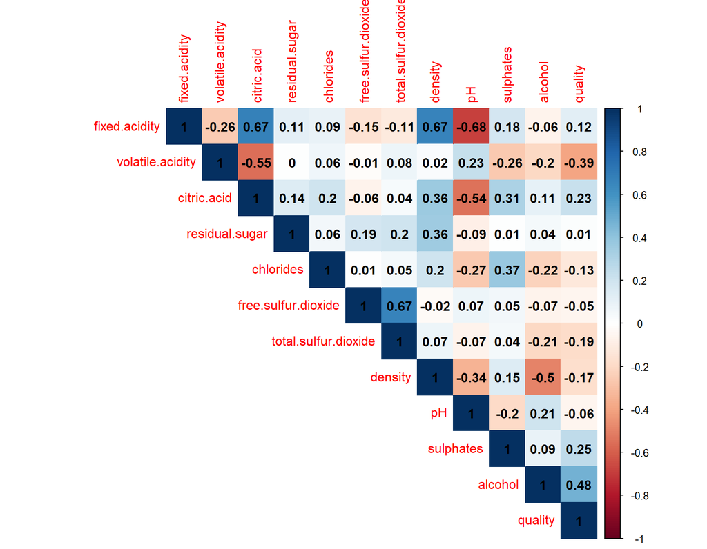

### Correlation:

- alcohol (positive correlation with quality )
- volatile acidity (negative correlation with quality)
- citric acid (positive correlation with quality )
- sulphates (positive correlation with quality )
- Density (negative correlation with quality & positive correlation with fixed acidity )

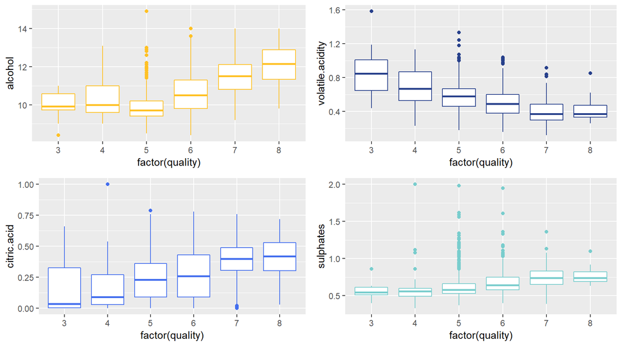

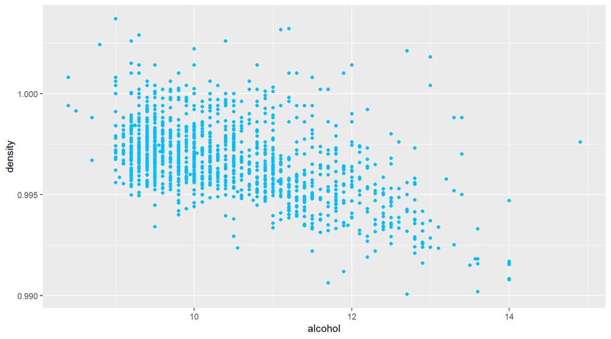

- Negative correlation between alcohol and density

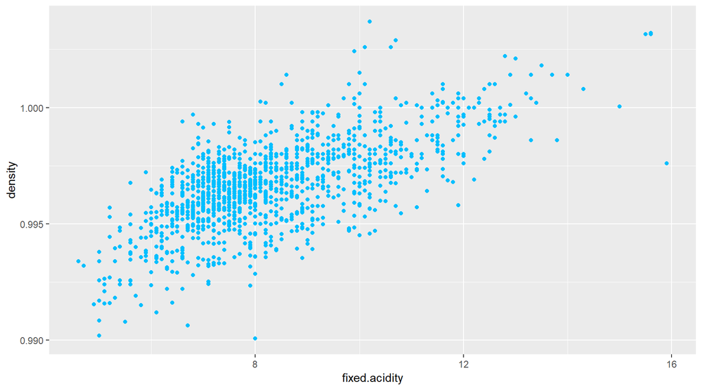

- Positive correlation between fixed acidity & Density which mean the acid make the wine more intense

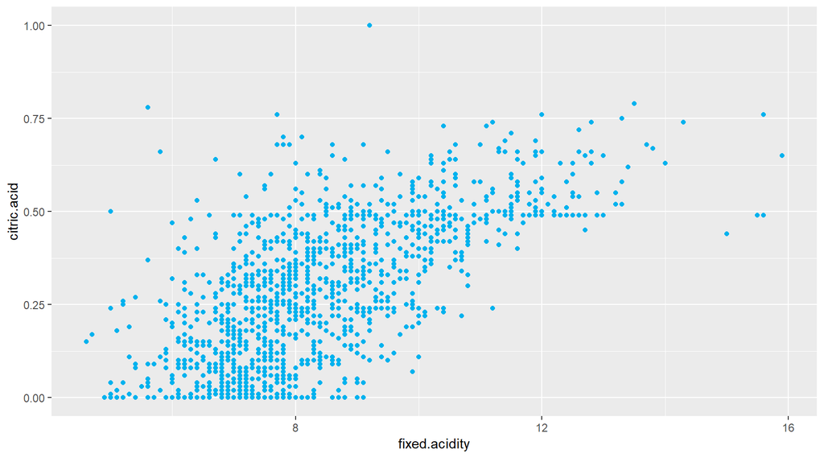

-Positive correlation between critic acid and fixed acidity

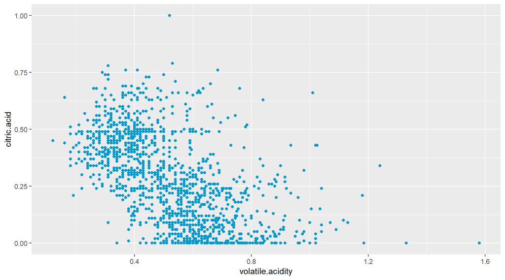

- Negative correlation between critic acid and volatile acidity

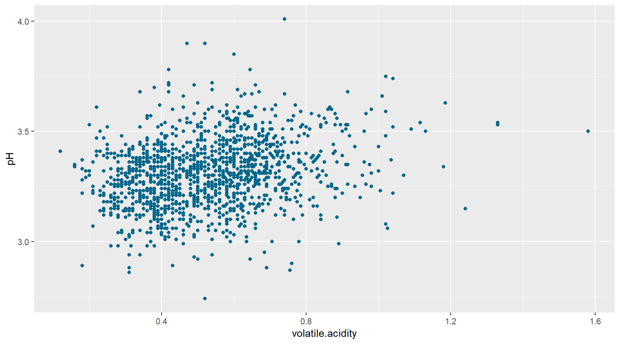

- The correlation is low between pH & volatile acidity

# Bivariate Analysis

### Did you observe any interesting relationships between the other features (not the main feature(s) of interest)?

pH & volatile acidity

### What was the strongest relationship you found?

as shown in the correlation table above > between pH and Fixed acidity -0.683

# Multivariate Plots Section

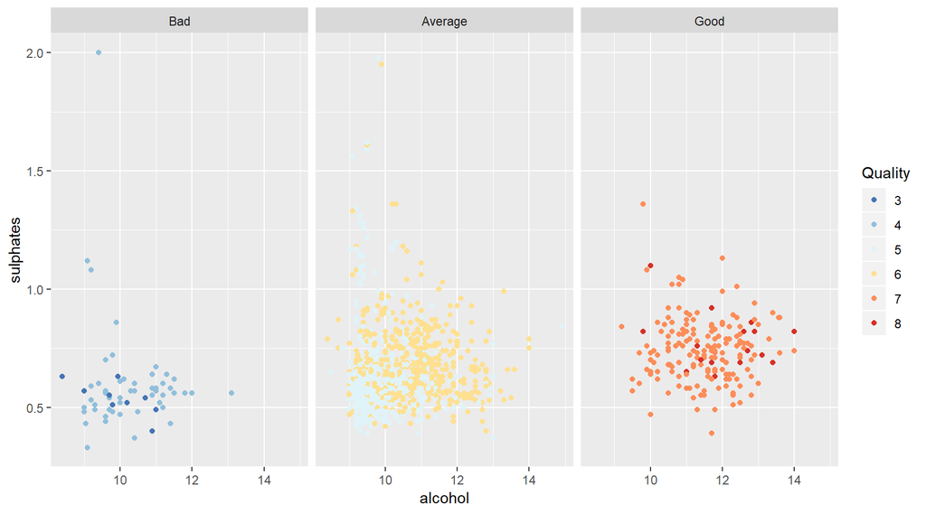

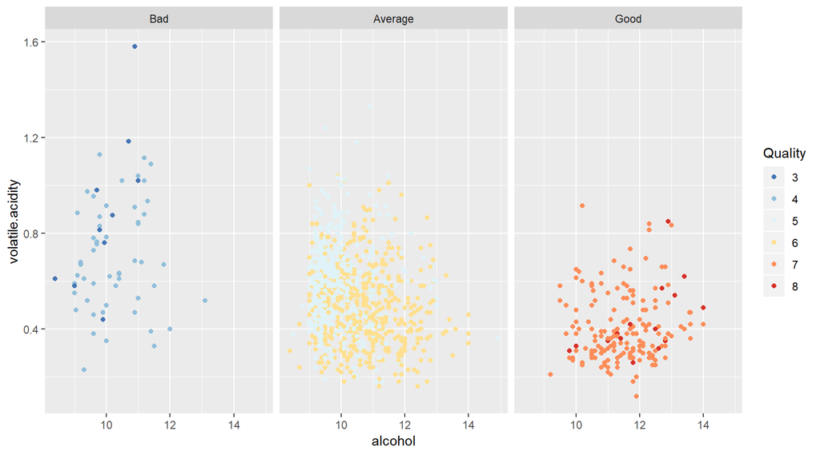

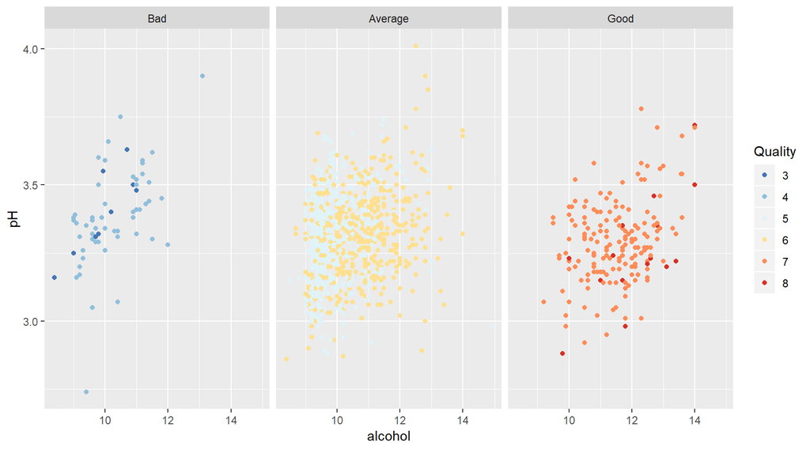

-As we see in the 3 above plots the increase in alcohol & sulphate and the decrease in volatile acidity make better quality

### Talk about some of the relationships you observed in this part of the investigation. Were there features that strengthened each other in terms of looking at your feature(s) of interest?

The increasing in alcohol & sulphate strengthened the wine quality

### Were there any interesting or surprising interactions between features?

Not much, but the fact that more than one variable (alcohol & sulphate) affect the quality of the win because I was thought that only alcohol & citric acid (not have that much effect) well have the strongest effect.

# Final Plots and Summary

### Plot One

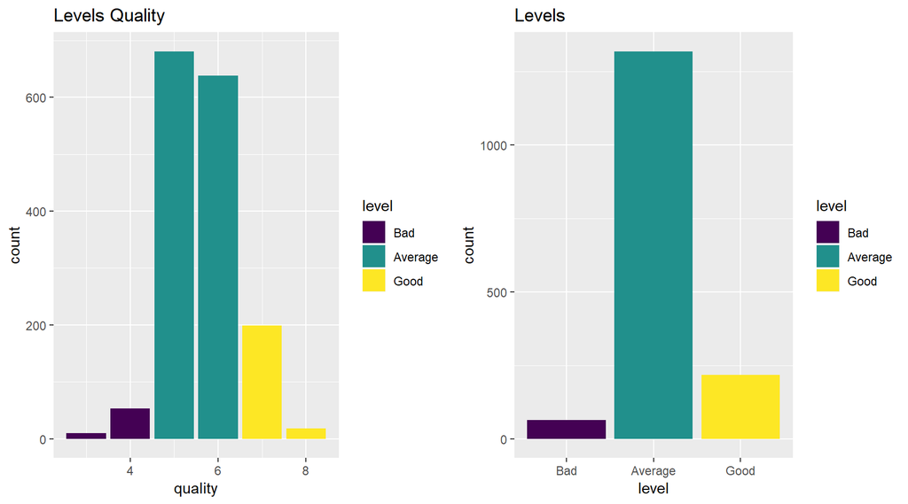

### Description One

The majority in this dataset (more than 1000) are an average qualitdy which is not actually lead us to analyze the good quality or what is the real features that may strongly affect it directly. So we can take the majortiy of the analysis here for the average quality red wines beacuse it is limited dataset.

### Plot Two

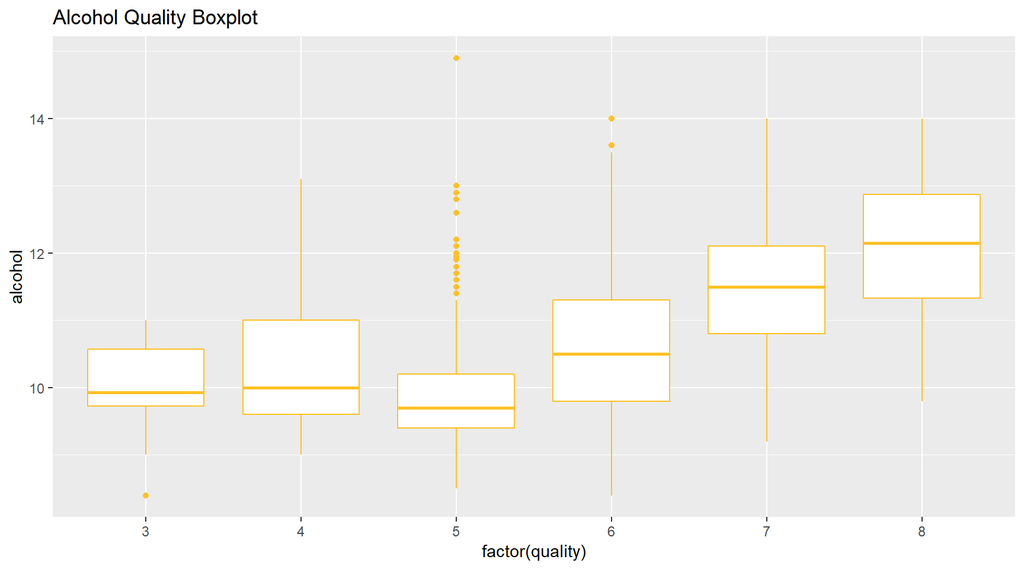

### Description Two

Alcohol & Quality Boxplot show the great impact of alcohol on the quality, as we say before it increase the wine quality, therefore, in this plot we can see the quality is normally distributed because the correspond in mean and median. so we can say that the median high value means that alcohol is also high.

### Plot Three

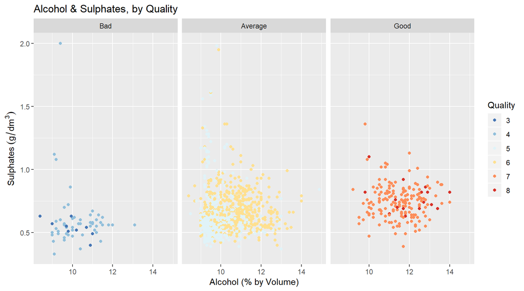

### Description Three

The above plot show that the increasing in both alcohol & sulphates together produce better quality wine

# Reflection

First, it difficult project since it is requires a lot of knowledge about wine to analyze this dataset the majority of my time goes to the reading about the wine and the R programing langauge is new to me.

Also as I said before the dataset is limited that maybe not be really sufficient analysis to depend on to know the “Good” quality wines, It maybe helps only the “Average” quality wines producers to apply such analysis. Here the most interesting finding and may help in a future analysis that alcohol & sulphate make better wine quality. For future analysis may add more data to this dataset to get enough useful information to produce high-quality red wine and expand on the analysis of alcohol&sulphate may lead to perfect quality.